# Greenhouse Gas Emissions 2018

Gabriel Berlin

11/29/2019

# The Greenhouse gas reporting program is a program run by the Environmental Protection Agency that requires all U.S. facilities emitting over 25,000 metric tons of CO2 per year to record and report their emissions. The EPA makes these data publicly available.

# In this project I will look at greenhouse gas emissions across industries and states. Knowing the source of emissions will help more effectively reduce those emissions.

# Carbon dioxide is the greenhouse gas that is emitted most, but it is not the most potent greenhouse gas. Methane is several times more potent than Carbon Dioxide, so I will also be looking at methane emissions.

## Load packages and data

### Packages

```r
# clear environment
rm(list = ls())

# load pakcages
library(DataComputing)
library(tidyverse)
library(lubridate)
library(ggplot2)
library(mosaic)
library(mosaicData)
library(readr)
library(maps)
library(rvest)
```

### Data

```r
fullEmissionsTable <- read_csv("direct_emitters.csv", skip = 3)
```

```
32 parsing failures.
 row                                                   col           expected       actual                  file
1007 Titanium Dioxide Production                           1/0/T/F/TRUE/FALSE 366,878.80   'direct_emitters.csv'
1009 HCFC–22 Production from HFC–23 Destruction            1/0/T/F/TRUE/FALSE 3,276,290.80 'direct_emitters.csv'
1011 HCFC–22 Production from HFC–23 Destruction            1/0/T/F/TRUE/FALSE 20.72        'direct_emitters.csv'
1202 Petroleum and Natural Gas Systems – LNG Import/Export 1/0/T/F/TRUE/FALSE 50714.204    'direct_emitters.csv'
1379 Titanium Dioxide Production                           1/0/T/F/TRUE/FALSE 254,011.10   'direct_emitters.csv'
.... ..................................................... .................. ............ .....................
See problems(...) for more details.
```

```r
data("ZipGeography")
```

## View data

### View emissions table data

```r
names(fullEmissionsTable)
```

```
 [1] "Facility Id"
 [2] "FRS Id"
 [3] "Facility Name"
 [4] "City"
 [5] "State"
 [6] "Zip Code"
 [7] "Address"
 [8] "County"
 [9] "Latitude"
[10] "Longitude"
[11] "Primary NAICS Code"
[12] "Industry Type (subparts)"
[13] "Industry Type (sectors)"
[14] "Total reported direct emissions"
[15] "CO2 emissions (non-biogenic)"
```

[output cut: 51 more lines]

```r
head(fullEmissionsTable, 10)
```

| Facility Id | FRS Id | Facility Name | City | State | Zip Code | Address | County | Latitude | Longitude | Primary NAICS Code | Industry Type (subparts) | Industry Type (sectors) | Total reported direct emissions | CO2 emissions (non-biogenic) | Methane (CH4) emissions | Nitrous Oxide (N2O) emissions | HFC emissions | PFC emissions | SF6 emissions | NF3 emissions | Other Fully Fluorinated GHG emissions | HFE emissions | Very Short-lived Compounds emissions | Other GHGs (metric tons CO2e) | Biogenic CO2 emissions (metric tons) | Stationary Combustion | Electricity Generation | Adipic Acid Production | Aluminum Production | … |
| --- | --- | --- | --- | --- | --- | --- | --- | --- | --- | --- | --- | --- | --- | --- | --- | --- | --- | --- | --- | --- | --- | --- | --- | --- | --- | --- | --- | --- | --- | --- |
| 1004377 | 110043803578 | 121 REGIONAL DISPOSAL FACILITY | MELISSA | TX | 75454 | 3820 SAM RAYBURN HIGHWAY | COLLIN COUNTY | 33.30 | -96.54 | 562212 | HH | Waste | 653854.00 | NA | 653854.00 | NA | NA | NA | NA | NA | NA | NA | NA | NA | NA | NA | NA | NA | NA | … |
| 1010040 | 110070082056 | 15-18565/15-18662 | Hazard | KY | 40701 | 4200 S. Hwy 15 | PERRY COUNTY | 37.22 | -83.16 | 212112 | FF | Other | 125981.75 | NA | 125981.75 | NA | NA | NA | NA | NA | NA | NA | NA | NA | NA | NA | NA | NA | NA | … |
| 1012147 | 110070082172 | 17Z Gas Plant - Chevron USA Inc. | McKittrick | CA | 93251 | 22845 Highway 33 | NA | 35.32 | -119.63 | 211130 | C,NN-FRAC,W-PROC | Natural Gas and Natural Gas Liquids Suppliers,Petroleum and Natural Gas Systems | 3564.14 | 3485.6 | 76.75 | 1.79 | NA | NA | NA | NA | NA | NA | NA | NA | NA | 3483.19 | NA | NA | NA | … |
| 1010085 | 110055519176 | 15-19015 | Hazard | KY | 41701 | 1845 S. KY HWY 15 | PERRY | 37.24 | -83.18 | 212112 | FF | Other | 93918.75 | NA | 93918.75 | NA | NA | NA | NA | NA | NA | NA | NA | NA | NA | NA | NA | NA | NA | … |
| 1000112 | 110019827286 | 23rd and 3rd | BROOKLYN | NY | 11232 | 730 3rd Avenue | Kings | 40.66 | -74.00 | 221112 | C,D | Power Plants | 70705.29 | 70633.5 | 32.75 | 39.04 | NA | NA | NA | NA | NA | NA | NA | NA | NA | 250.10 | 70455.19 | NA | NA | … |
| 1003742 | 110010392887 | 31st Street Landfill | WESTCHESTER | IL | 60154 | 11700 W 31ST ST | COOK COUNTY | 41.84 | -87.92 | 562212 | C,HH | Waste | 31220.15 | 168.4 | 31051.75 | NA | NA | NA | NA | NA | NA | NA | NA | NA | NA | 168.40 | NA | NA | NA | … |
| 1003188 | 110000599273 | 3M BROWNWOOD | BROWNWOOD | TX | 76801 | 4501 HIGHWAY 377 SOUTH | BROWN | 31.67 | -99.00 | 326113 | C,N | Minerals | 34432.42 | 34396.8 | 16.25 | 19.37 | NA | NA | NA | NA | NA | NA | NA | NA | NA | 34265.42 | NA | NA | NA | … |
| 1005043 | 110035810799 | 3M CO | MAPLEWOOD | MN | 55144 | NA | RAMSEY COUNTY | 44.95 | -93.00 | 541715 | C | Other | 104995.53 | 104883.3 | 50.25 | 61.98 | NA | NA | NA | NA | NA | NA | NA | NA | NA | 104995.53 | NA | NA | NA | … |
| 1003739 | 110000589159 | 3M CO - GUIN | GUIN | AL | 35563 | 6675 US HIGHWAY 43 | MARION | 33.97 | -87.90 | 326113 | C,N | Minerals | 28622.30 | 28593.8 | 13.00 | 15.50 | NA | NA | NA | NA | NA | NA | NA | NA | NA | 27795.90 | NA | NA | NA | … |
| 1012037 | 110067543885 | 50 Buttes Gas Plant | Gillette | WY | 82716 | 3669 South Hwy 50 | NA | 43.76 | -105.79 | 213112 | C,W-PROC | Petroleum and Natural Gas Systems | 77649.48 | 72329.2 | 5279.75 | 40.53 | NA | NA | NA | NA | NA | NA | NA | NA | NA | 70785.98 | NA | NA | NA | … |

The table’s columns contain information about three different things: information about the facility, actual emissions data, and how gasses were emitted. How gasses were emitted is beyond the scopeof the research question, so I will focus on only the first two categories and I will get rid of the variables I do not need.

## Data wrangling

### Data wrangling of emissions table

```r
emissionsTable <-
  fullEmissionsTable %>%
  rename(sector = `Industry Type (sectors)`) %>%
  select(`Facility Id`, `FRS Id`, `Facility Name`, `State`, Latitude, Longitude,
         `sector`, `Total reported direct emissions`,
         `CO2 emissions (non-biogenic)`, `Methane (CH4) emissions`,
         `Nitrous Oxide (N2O) emissions`, `HFC emissions`, `PFC emissions`, `SF6 emissions`,
         `NF3 emissions`, `Other Fully Fluorinated GHG emissions`, `HFE emissions`,
         `Other GHGs (metric tons CO2e)`, `Biogenic CO2 emissions (metric tons)`)
```

#### List of sectors/industries

```r
emissionsTable %>%
  group_by(sector) %>%
  summarise(total = n()) %>%
  arrange(desc(total))
```

| sector | total |
| --- | --- |
| Power Plants | 1352 |
| Waste | 1217 |
| Petroleum and Natural Gas Systems | 1143 |
| Other | 1056 |
| Minerals | 371 |
| Chemicals | 334 |
| Metals | 285 |
| Pulp and Paper | 128 |
| Other,Waste | 122 |
| Natural Gas and Natural Gas Liquids Suppliers,Petroleum and Natural Gas Systems | 101 |

[output cut: 52 more lines]

There are multiple sectors in some of the values. For example, “Chemicals,Coal-based Liquid Fuel Supply,Suppliers of CO2”. Because there are multiple values in a single cell, this data is not in tidy form. To make it in tidy form I will make sure there is only one value in a cell. Additionally, these details are not relevant. I will need to use regular expressions and a loop to replace the values.

#### Set the sectors equal to simplified versions

```r
chem <- "Chemicals"
metals <- "Metals"
minerals <- "Minerals"
natural <- "Natural Gas"
other <- "Other"
petro <- "Petroleum"
paper <- "Pulp"
power <- "Power Plants"
injection <- "Injection"

s <- "" # variable needed to loop through table
i <- 0 # for loop counter variable

for (i in 1:nrow(emissionsTable)) {
  s <- emissionsTable[i, "sector"]  # access sector value in each row
  if (grepl(pattern = "^Chemical", s)) {
    emissionsTable[i, "sector"] = chem
  }  else if (grepl(pattern = "^Metals", s)) {
    emissionsTable[i, "sector"] = metals
  } else if (grepl(pattern = "^Minerals", s)) {
    emissionsTable[i, "sector"] = minerals
  } else if (grepl(pattern = "^Natural", s)) {
    emissionsTable[i, "sector"] = natural
  } else if (grepl(pattern = "^Petroleum", s)) {
    emissionsTable[i, "sector"] = petro
  } else if (grepl(pattern = "^Pulp", s)) {
    emissionsTable[i, "sector"] = paper
  } else if (grepl(pattern = "^Injection", s)) {
   emissionsTable[i, "sector"] = injection
  } else if (grepl(pattern = "^Power Plant", s)) {
    emissionsTable[i, "sector"] = power
  } else {
    emissionsTable[i, "sector"] = other
  }
}
```

# Now that the data is in glyph ready form, I will display tables and graphs of the data

## View all emissions by sector

```r
StateSectorEmissions <-
  emissionsTable %>%
  group_by(sector, State) %>%
  summarise(emissions = sum(`Total reported direct emissions`), carbon = sum(`CO2 emissions (non-biogenic)`, na.rm = TRUE), methane = sum(`Methane (CH4) emissions`, na.rm = TRUE)) %>%
  arrange(desc(emissions))
SectorEmissions <-
  StateSectorEmissions %>%
  group_by(sector) %>%
  summarise(emissions = sum(emissions), carbon = sum((carbon), na.rm = TRUE), methane = sum(methane, na.rm = TRUE))
StateSectorEmissions
```

| sector | State | emissions | carbon | methane |
| --- | --- | --- | --- | --- |
| Power Plants | TX | 208957303.41 | 208012035.3 | 317688.66 |
| Power Plants | FL | 102041680.15 | 101665839.7 | 152573.35 |
| Chemicals | TX | 88354809.83 | 86651426.4 | 404245.75 |
| Power Plants | IN | 83402996.94 | 82850711.2 | 193293.50 |
| Power Plants | OH | 76033302.04 | 75576268.0 | 159917.88 |
| Power Plants | PA | 74679721.80 | 74310428.4 | 122228.46 |
| Power Plants | KY | 66489078.36 | 66023593.4 | 157524.34 |
| Power Plants | MO | 63499883.17 | 63098780.0 | 99776.00 |
| Power Plants | MI | 61456516.47 | 61107226.4 | 107039.00 |
| Power Plants | AL | 57096825.91 | 56806878.5 | 107605.09 |

[output cut: 336 more lines]

```r
SectorEmissions
```

| sector | emissions | carbon | methane |
| --- | --- | --- | --- |
| Chemicals | 300301927 | 271206870 | 1339123.5 |
| Injection | 14656243 | 14457056 | 149573.0 |
| Metals | 99785706 | 96732985 | 612014.5 |
| Minerals | 116776832 | 115817707 | 778235.5 |
| Natural Gas | 14170754 | 13555012 | 606237.2 |
| Other | 249705514 | 116722395 | 126628830.2 |
| Petroleum | 169062052 | 159728373 | 9062263.2 |
| Power Plants | 1773703261 | 1764231595 | 3245135.9 |
| Pulp | 40167086 | 35010099 | 4651696.5 |

This table shows that power plants are, by far, the biggest polluter out of all industries in the economy.

# Data Visualizaitons

## Emissions for all facilities

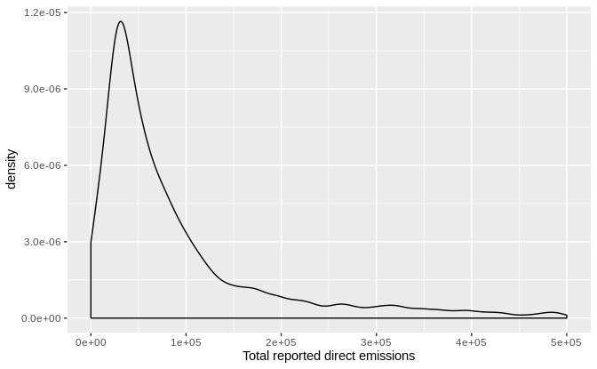

```r
emissionsTable %>%
  ggplot(aes(x = `Total reported direct emissions`)) + geom_density() + xlim(0, 500000)
```

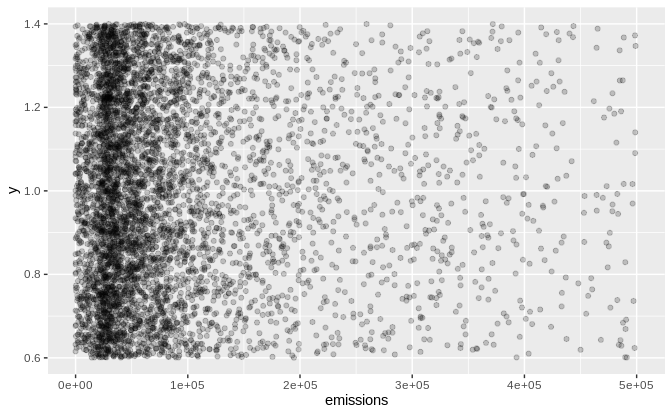

```r
emissionsTable %>%
  ggplot(aes(x = `Total reported direct emissions`, y = 1)) + geom_point(alpha = .2, position = "jitter") + xlab("emissions") + xlim(0, 500000)
```

This shows that the vast majority of facilities emit between 0 and 100,000 metric tons of greenhouse gasses.

## Barchart of emissions by sector

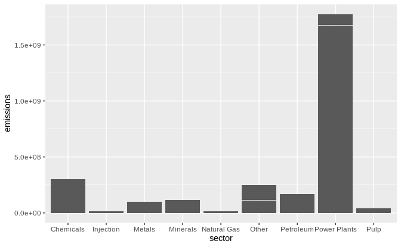

```r
StateSectorEmissions %>%
  ggplot(aes(x = sector, y = emissions)) + geom_bar(stat = "identity")
```

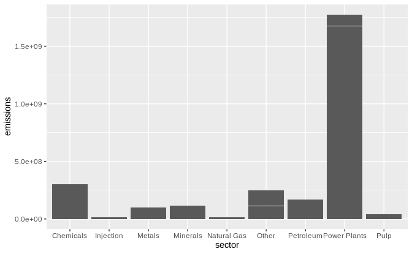

```r
StateSectorEmissions %>%
  ggplot(aes(x = sector, y = emissions)) + geom_bar(stat = "identity")
```

## View CO2 and methane emissions by sector

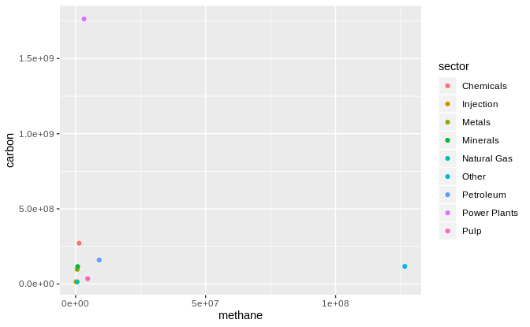

```r
ggplot(data = SectorEmissions, aes(x = methane, y = carbon)) + geom_point(aes(color = sector))
```

## View CO2 and methane emissions by state and sector

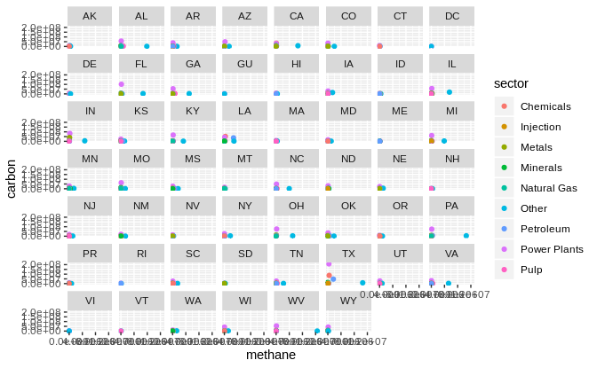

```r
ggplot(data = StateSectorEmissions, aes(x = methane, y = carbon)) + geom_point(aes(color = sector))+ facet_wrap(. ~ State)
```